# Network Assignment

# 15) Calculate Betweenness centrality measure, find its correlation with the eigenvector centrality

Plot it properly.

The `betwenness centrality` says how much paths between any other nodes go trough that node.

This idea is based #in part, on a seminal #paper by Mark Granovetter called `"The strength of weak ties"` in which it was shown that most job seekers (who participated in the study) found their ultimate employment through a weak tie, that is, through an acquaintance, rather than a strong tie or a close friend.

```r
betwenness = betweenness(g1)

sort(betwenness,decreasing=TRUE)[1:10]
```

```
##    Medici  Guadagni   Albizzi  Salviati   Ridolfi  Bischeri   Strozzi Barbadori
##    47.500    23.167    19.333    13.000    10.333     9.500     9.333     8.500
## Tornabuon Castellan
##     8.333     5.000
```

```r
cor(betwenness,eigencen)
```

```
## [1] 0.6737
```

Plot based on betwenness

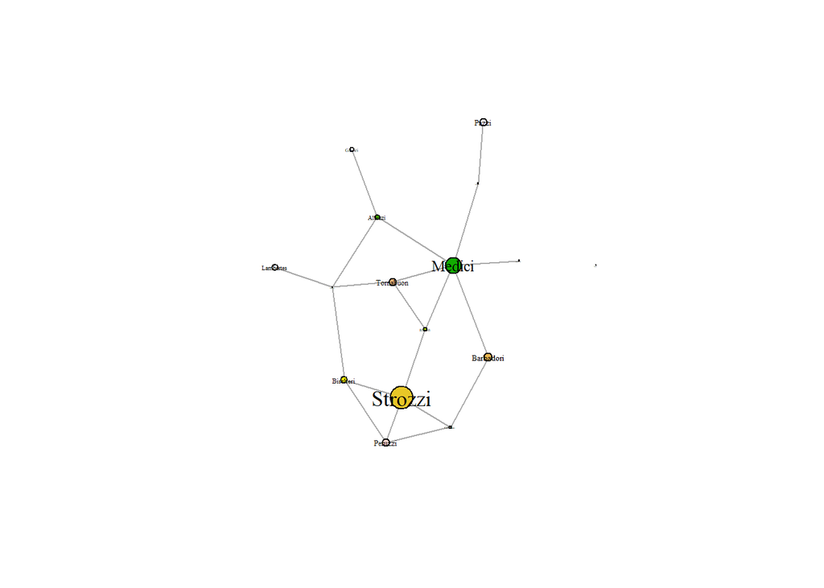

```r
bins <- unique(quantile(betwenness, seq(0,1,length.out=30)))
vals <- cut(betwenness, bins, labels=FALSE, include.lowest=TRUE)

colorVals <- rev(terrain.colors(length(bins)))[vals]
V(g1)$color <- colorVals
set.seed(1)
plot.igraph(g1, vertex.size=V(g1)$wealth/10,
            vertex.label.cex=V(g1)$wealth*0.0075,
            vertex.label.color="black")
```

# 16) Calculate the Edge Betweenness centrality measure it is basically a clustering measure and plot it

`Its a clustering measure`. The measure helps to find the `community`, and isolate them,

```r
w <- edge.betweenness.community(g1)
sort(table(w$membership))
```

```
##
## 5 4 1 2 3
## 1 2 4 4 5
```

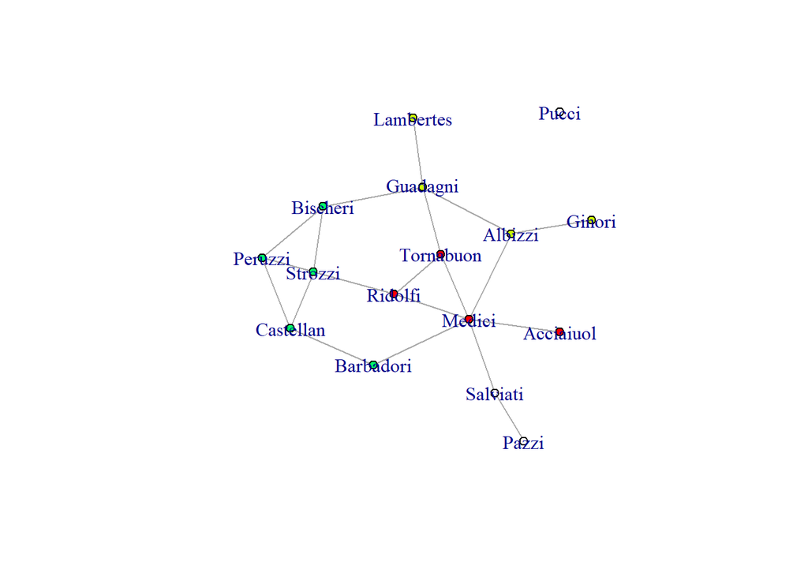

```r
V(g1)$color <- rep("white", length(w$membership))
keepTheseCommunities <- names(sizes(w))[sizes(w) > 3]
matchIndex <- match(w$membership, keepTheseCommunities) # like %in%
colorVals <- rainbow(5)[matchIndex[!is.na(matchIndex)]]
V(g1)$color[!is.na(matchIndex)] <- colorVals


plot.igraph(g1, vertex.size=5,vertex.label.cex=1)
```